# What Makes an NFL Playoff Team? An Analysis and Prediction of NFL Playoff Teams.

Hunter Blum

11/19/2020

## Introduction

According to USA Today, the NFL is the most valuable sports league in the world, generating 16 billion dollars in revenue last year (Colangelo, 2019). With so much money on the line, it is imperative that teams are able to be the best possible, in order to increase popularity and revenue. But what position should teams invest money into? The historic answer has been positions such as quarterback and defenesive end, but does the math work out?

In this project, I will be analyzing a few questions to hopefully help NFL general managers and sports bettors alike. First, I will be scrutinizing the age-old talking point that special teams can make or break a season for a team. Then I will analyze which stats, and therefore positions, are most indicative of a playoff team. Finally, I will create a model to predict which teams will make the playoffs based on team statistics. This model will not account for wins, allowing its predicative ability to be used in the preseason by simply making the necessary additions and subtractions to each teams roster, and recalcuating all of their statistics.

## The Data

The data for this project was scraped from pro-football-reference.com on November 19, 2020. The code for scraping the data can be found in the FinalNFLScrape.rmd file included in the project submission. The data includes a multitude of team statistics from each NFL season dating from 1970 until the date of the most recent web scrape. An explanation of each variable within the data can be found within the NFL Dataset Variable Key word file included in the project submission.

```r
# Original Data
NFL <- read.csv("NFL.csv")

# Libraries Used
library(plyr)
library(car)
library(DescTools)
library(vegan)
library(fpc)
library(biotools)
library(Hotelling)
library(tidyverse)
```

## Cleaning the Data

I started by removing the variable TB. (touchback percentage), KOAvg (kickoff average), and DefPercentScore, since they were not recorded until the late 1980s. In preliminary statistical tests, some of my variables were highly correlated to each other, so I chose the variable that was more simple (if both were based on an equation such as passing touchdowns per game (PassTDG) vs. percent of throws that are passing touchdowns (PassTD)). I also did some cleaning to the variable names to remove periods and removed the percentage sign for some variables, so they could be stored as numeric. Finally, I split the dataset to store 2020 in a seperate dataframe. This way the data used for analysis is 100% accurate on who is and is not a playoff team (since we are only about halfway through this NFL season and do not know the actual playoff teams yet).

```r
NFL$FG. <- NFL$FG. %>% str_remove("%")
NFL$XP. <- NFL$XP. %>% str_remove("%")
NFL <- NFL %>% rename(FG=FG., XP= XP., PassCmp=PassCmp., PassTD=PassTD., PassSack=PassSack., TB=TB.)
NFL$FG <- as.numeric(NFL$FG)
NFL$XP <- as.numeric(NFL$XP)

NFL$TB <- NULL
NFL$KOAvg <- NULL
NFL$DefPercentScore <- NULL

# What I used to assess the highest correlation between variables. I removed variables one at a time, then decreased the amount of variables in my code, removing variables until the data set worked for my tests.

NFL2 <- NFL[,7:56]
z <- cor(NFL2)
z[lower.tri(z,diag=TRUE)]=NA
z=as.data.frame(as.table(z))
z=na.omit(z)
z=z[order(-abs(z$Freq)),]
z
```

```
##               Var1          Var2          Freq
## 455       PassAY.A     PassANY.A  0.9747514185
## 355       PassAY.A      PassRate  0.9638374582
## 458       PassRate     PassANY.A  0.9603636327
## 2191   DefPassYdsG    DefPassFDG  0.9420859174
## 404        PassY.A      PassNY.A  0.9142760131
## 459       PassNY.A     PassANY.A  0.9127794562
## 2190       DefCmpG    DefPassFDG  0.9090713885
## 1734        DefY.P       DefNY.A  0.9071934776
## 2345   DefRushYdsG    DefRushFDG  0.9014503776
## 711       PassSack     PassSackG  0.8949464821
## 602         PassTD       PassTDG  0.8825962932
## 2040       DefCmpG   DefPassYdsG  0.8783834634
## 405       PassAY.A      PassNY.A  0.8734414977
## 351        PassCmp      PassRate  0.8685578759
```

[output cut: 1211 more lines]

```r
# Variables that I removed because of high correlations or being based on a single play.

NFL$PassYds7G <- NULL
NFL$PassANY.A <- NULL
NFL$PassRate <- NULL
NFL$DefPassFDG <- NULL
NFL$PassNY.A <- NULL
NFL$DefNY.A <- NULL
NFL$DefRushFDG <- NULL
NFL$PassSack <- NULL
NFL$PassYds19G <- NULL
NFL$PassTD <- NULL
NFL$DefCmpG <- NULL
NFL$PassY.A <- NULL
NFL$DefIntG <- NULL
NFL$RushAttG <- NULL
NFL$DefPenYdsG <- NULL
NFL$PassAttG <- NULL
NFL$APYd <- NULL
NFL$PuntRetLng <- NULL
NFL$PassLng <- NULL
NFL$RushLng <- NULL
NFL$KickRetLng <- NULL
NFL$FGLng <- NULL

# Splitting between 2019 and 2020
NFL2020 <- NFL %>% filter(Year==2020)
NFL <- NFL %>% filter(Year!=2020)
```

## Hotellings T2: Does special teams matter?

Often times announcers will bring particular attention to special teams, especially when there is a mistake on a play. This is usually followed by a statement of how special teams makes or breaks a team’s success. So, I performed a Hotellings T2 test to determine if the mean special teams stats varied between playoff and non-playoff teams. My null hypothesis is that playoff and non-playoffs have equal stats across the special teams categories. My alternative hypothesis is that the mean special teams stats differ between playoff and non-playoff teams.

The test returned a statistic of 7.86 and a p-value of 2.3x10^-9 at seven and 1469 degrees of freedom. Since the test returned a significant p-value, we can reject the null hypothesis and conclude that playoff teams and non-playoff teams differ significantly in their special team statistics.

```r
NFLSpecialTeams <- NFL %>% dplyr::select(Playoffs, PuntYds.R:KickRetTDG, FG:Yds.Punt)

T2Test <- hotelling.test(.~Playoffs, data=NFLSpecialTeams)
T2Test
```

```
## Test stat:  7.8581
## Numerator df:  7
## Denominator df:  1469
## P-value:  2.254e-09
```

## MANOVA with Bonferroni Confidence Intervals

I performed a MANOVA to determine if there was a difference in the team statistics between playoff teams and non-playoff teams. The null-hypothesis for my MANOVA is that there is no difference between playoff and non-playoff teams in my chosen stats, while the alternative hypothesis is that there is at least one statistic that is significantly different between playoff and non-playoff teams. My MANOVA returned a Wilks-lambda test statistic of .50 with a p-value of 2.22x10^-16 at 30 and 1446 degrees of freedom. Since the test was significant, we can conclude that at least one of the statistics is significantly different between playoff and non-playoff teams.

```r
# MANOVA
NFLMan <- NFL %>% select(6:36)
NFLMan$Playoffs <- as.factor(NFLMan$Playoffs)

fit.lm <- lm(cbind(PassCmp, PassAY.A, PassY.C, PassY.G, PassTDG, PassIntG, PassSackG, RushY.A, RushY.G, RushTDG, RushFmbG, PuntYds.R, KickYds.R, PuntRetTDG, KickRetTDG, APYdG, FG, XP, Yds.Punt, DefY.P, DefRushY.A, DefPAG, DefTOG, DefFirstDownG, DefPassYdsG, DefPassTDG, DefRushYdsG, DefRushTDG, DefPenG, DefPenFirstG)~Playoffs, data=NFLMan)

fit.manova <- Manova(fit.lm)
summary(fit.manova)
```

```
##
## Type II MANOVA Tests:
##
## Sum of squares and products for error:
##                     PassCmp      PassAY.A       PassY.C       PassY.G
## PassCmp        40173.625918  6.319194e+03 -3.862507e+03  225089.56864
## PassAY.A        6319.193607  1.910252e+03  3.125391e+02   49806.14794
## PassY.C        -3862.506761  3.125391e+02  1.925785e+03   -4847.49056
## PassY.G       225089.568638  4.980615e+04 -4.847491e+03 2544999.77557
## PassTDG         1681.859254  4.938807e+02  7.455450e+01   18221.36711
## PassIntG       -1353.039056 -3.797546e+02  1.616892e+02   -4666.48443
## PassSackG       -586.501782 -1.065703e+02  2.882367e+01   -8822.73839
## RushY.A          431.429285  1.648527e+02  3.886078e+01     235.78419
## RushY.G       -51840.707936 -3.350568e+03  1.366589e+04 -642643.39785
## RushTDG          -36.435850  7.427827e+01  1.704965e+02   -1049.54292
## RushFmbG       -1687.887124 -2.858231e+02  2.326275e+02  -10692.86293
## PuntYds.R        598.583648  1.633518e+02 -1.379840e+02    1134.14606
## KickYds.R       2990.897260  3.467848e+02 -5.401995e+02    3805.81497
## PuntRetTDG        -2.155045 -8.857209e-01 -2.123360e+00     -65.16043
## KickRetTDG        -3.415637  1.804891e-02 -8.558623e-01    -131.79646
## APYdG         110600.075177  3.366713e+04  1.283716e+04 1468965.89462
## FG             42926.238017  6.416918e+03 -7.033173e+03  282696.20313
## XP              3811.163171  5.721342e+02 -9.314199e+02   30389.43475
## Yds.Punt        7914.171146  1.160791e+03 -1.346927e+03   51913.43092
## DefY.P          1705.628072  3.182284e+02 -1.630090e+02   14522.70704
## DefRushY.A       858.765432  1.657276e+02 -6.683501e+01    6008.67155
## DefPAG          5777.676306  8.464109e+02 -6.137755e+02   80046.57713
## DefTOG         -1984.065170 -2.786588e+02  3.367771e+02  -13336.94056
## DefFirstDownG   4337.893203  9.541584e+02 -2.759724e+02   47521.14147
## DefPassYdsG   133337.869238  2.627682e+04 -1.379019e+04 1241780.44875
## DefPassTDG       831.139461  1.539808e+02 -7.044065e+01    8787.61311
## DefRushYdsG   -47144.111495 -8.705188e+03  5.728292e+03 -320902.67937
## DefRushTDG      -306.442020 -4.868480e+01  6.538966e+01    -440.21707
## DefPenG          450.732852  9.276507e+01 -1.041968e+02    9603.31318
## DefPenFirstG     650.800507  1.385482e+02 -6.542959e+01    6282.12888
##                     PassTDG      PassIntG     PassSackG      RushY.A
## PassCmp        1.681859e+03 -1.353039e+03  -586.5017823  431.4292850
## PassAY.A       4.938807e+02 -3.797546e+02  -106.5703231  164.8526607
## PassY.C        7.455450e+01  1.616892e+02    28.8236722   38.8607802
## PassY.G        1.822137e+04 -4.666484e+03 -8822.7383924  235.7841888
```

[output cut: 460 more lines]

```
## DefPassYdsG     33.48925280   7.694659384
## DefPassTDG       1.61398720   0.370837827
## DefRushYdsG    153.93293612  35.368406655
## DefRushTDG       2.08540652   0.479153504
## DefPenG          0.19027942   0.043719559
## DefPenFirstG     0.04371956   0.010045226
##
## Multivariate Tests: Playoffs
##                  Df test stat approx F num Df den Df     Pr(>F)
## Pillai            1 0.4976691 47.75269     30   1446 < 2.22e-16 ***
## Wilks             1 0.5023309 47.75269     30   1446 < 2.22e-16 ***
## Hotelling-Lawley  1 0.9907198 47.75269     30   1446 < 2.22e-16 ***
## Roy               1 0.9907198 47.75269     30   1446 < 2.22e-16 ***
## ---
## Signif. codes:  0 '***' 0.001 '**' 0.01 '*' 0.05 '.' 0.1 ' ' 1
```

```r
# Automated Bonferroni confidence intervals
NFLIntervals <- c()
for(i in NFLMan[,2:31]) {
res <- aov(formula = i ~ Playoffs, data=NFLMan)
CI <- PostHocTest(res, method = "bonferroni")
df<- data.frame(matrix(unlist(CI), nrow = length(CI), byrow=T))


NFLIntervals <- rbind(NFLIntervals, df)
}


Variables <- colnames(NFLMan[,2:31])
NFLIntervals$variable <- Variables
names(NFLIntervals) <- c("diff", "lower", "upper", "pval", "variable")


NFLIntervalsSig <- NFLIntervals %>% mutate(LowerCheck=ifelse(NFLIntervals$lower<0, -1, 1))

NFLIntervalsSig <- NFLIntervalsSig %>% mutate(UpperCheck=ifelse(NFLIntervals$upper<0, -1, 1))

NFLIntervalsSig <- NFLIntervalsSig %>% mutate(Direction= LowerCheck + UpperCheck)

NFLIntervalsSig <- NFLIntervalsSig %>% filter(Direction!=0)  %>%  mutate(PlayoffVsNo = ifelse(Direction>0, "Playoffs", "No"))

NFLIntervalsSig
```

```
##            diff        lower        upper          pval      variable
## 1    3.12558556   2.57458994   3.67658119  1.128079e-27       PassCmp
## 2    1.20437050   1.08422073   1.32452028  1.251004e-76      PassAY.A
## 3    0.43034285   0.30970557   0.55098012  3.943465e-12       PassY.C
## 4   17.80210670  13.41658253  22.18763086  3.336476e-15       PassY.G
## 5    0.31799903   0.27450042   0.36149764  9.286862e-44       PassTDG
## 6   -0.26979533  -0.30746582  -0.23212485  3.599932e-42      PassIntG
## 7   -0.48734765  -0.56158708  -0.41310821  4.905892e-36     PassSackG
## 8    0.09767539   0.05203937   0.14331142  2.849013e-05       RushY.A
## 9   13.88333902  11.44724700  16.31943104  6.593636e-28       RushY.G
## 10   0.23981626   0.20709761   0.27253491  5.780582e-44       RushTDG
## 11  -0.18780315  -0.23881767  -0.13678863  8.220316e-13      RushFmbG
## 12   0.40950201   0.17200303   0.64700099  7.379020e-04     PuntYds.R
## 13  19.28536021  15.35060123  23.22011919  2.882408e-21         APYdG
## 14   3.78630480   2.51338384   5.05922575  6.612970e-09            FG
```

[output cut: 35 more lines]

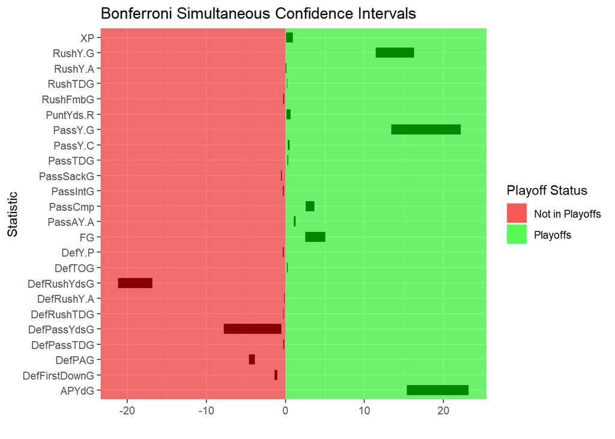

```r
segment_data = data.frame(
  x=c(NFLIntervalsSig$variable),
  xend=c(NFLIntervalsSig$variable),
  y=c(NFLIntervalsSig$lower),
  yend=c(NFLIntervalsSig$upper)
)



# Visualization of confidence intervals
ggplot(NFLIntervalsSig, aes(y=variable)) +
  geom_segment(aes(x=lower, xend= upper, y=variable, yend= variable), size=4) +
geom_rect(aes(linetype= "Playoffs",xmin=0, xmax=Inf, ymin= -Inf, ymax= Inf,), fill="green", alpha=.03) +
  geom_rect(aes(linetype= "Not in Playoffs",xmin=-Inf, xmax=0, ymin=-Inf, ymax=Inf), fill="red", alpha=.03) +
  ylab("Statistic") + xlab("")  + scale_linetype_manual(values=c("Playoffs"=0, "Not in Playoffs"=0), name="Playoff Status", guide=guide_legend(override.aes = list(fill= c("red", "green"), alpha=.4))) + ggtitle("Bonferroni Simultaneous Confidence Intervals")
```

# Principal Component Analysis

I have decided to use the first eight principal components of my analysis to create a reduced dataset. My scree plot begins to level off around the eighth PC and the eight PC marks where 70% of the of the variance is explained.

The first principal component appears to be a contrast between a mixture of variables that do not make much contextual sense when combined together. For example, DefTOG (turnovers taken by the defense) is without a doubt a positive statistic, however, it is given almost the same PC score and RushFmbG (rushing fumbles per game) which is a clear negative statistic. PC2 appears to be contrasting major offensive a defensive categories such as DefPAG (defensive points allowed per game) and PassAY.A (adjusted pass yards per attempt). The thrid PC is a combination of offensive statistics such as PassY.C (pass yards per completion) and defensive statistics such as DefRushTDG (rushing touchdowns given up by the defense per game). The fourth prinicpal component is a contrast between passing statistics and special teams statistics. PC 5 is a summation of punt return statistics, likely serving as a stand in to field position. PC 6 is another contrast that contextually does not make sense, like the first PC. The seventh PC is expalined by kick return yards and touchdowns. Finally, the eight PC is a contrast between defensive penalty statistics and extra point percentage.

I am not sure that this principal component analysis will be effective in helping reduce dimensions, since it takes many PCs to even get to 70% variance explained. To further evidence this, a plot of PC1 vs PC2 colored by whether the team does or does not make the playoffs does not show a definitive split between the two groups. However, I will continue to explore using both my raw data and PCA data (stored in NFLReduced) in subsequent analyses.

```r
NFL3 <- NFL[,7:36]
NFL3 <- scale(NFL3, center = T, scale=T)
NFL.pc <- prcomp(NFL3)
summary(NFL.pc)
```

```
## Importance of components:
##                           PC1    PC2    PC3     PC4     PC5     PC6     PC7
## Standard deviation     2.5928 2.0991 1.6532 1.37025 1.26674 1.23343 1.11791
## Proportion of Variance 0.2241 0.1469 0.0911 0.06259 0.05349 0.05071 0.04166
## Cumulative Proportion  0.2241 0.3710 0.4621 0.52465 0.57814 0.62885 0.67050
##                            PC8    PC9    PC10    PC11    PC12    PC13    PC14
## Standard deviation     1.05465 0.9612 0.94003 0.91862 0.85303 0.83302 0.76519
## Proportion of Variance 0.03708 0.0308 0.02946 0.02813 0.02426 0.02313 0.01952
## Cumulative Proportion  0.70758 0.7384 0.76783 0.79596 0.82022 0.84335 0.86287
##                           PC15    PC16    PC17    PC18    PC19    PC20    PC21
## Standard deviation     0.75644 0.73307 0.70429 0.69555 0.66081 0.62382 0.52499
## Proportion of Variance 0.01907 0.01791 0.01653 0.01613 0.01456 0.01297 0.00919
## Cumulative Proportion  0.88194 0.89985 0.91639 0.93251 0.94707 0.96004 0.96923
##                           PC22   PC23    PC24    PC25    PC26    PC27    PC28
## Standard deviation     0.48935 0.4581 0.38233 0.36289 0.26468 0.24166 0.20045
## Proportion of Variance 0.00798 0.0070 0.00487 0.00439 0.00234 0.00195 0.00134
## Cumulative Proportion  0.97721 0.9842 0.98908 0.99347 0.99580 0.99775 0.99909
##                           PC29    PC30
## Standard deviation     0.14269 0.08364
## Proportion of Variance 0.00068 0.00023
## Cumulative Proportion  0.99977 1.00000
```

```r
NFL.pc$rotation
```

```
##                        PC1          PC2          PC3          PC4           PC5
## PassCmp        0.289023051 -0.172797010  0.043481165 -0.088703507  0.1074753407
## PassAY.A       0.241994154 -0.279583946 -0.149344061 -0.157076449  0.0325574640
## PassY.C       -0.118056752 -0.111625236 -0.351279809 -0.154234801 -0.1501024177
## PassY.G        0.300149072 -0.111871394 -0.075863393 -0.317716911 -0.0897834973
## PassTDG        0.221493006 -0.181783779 -0.184396874 -0.281458385 -0.0733154608
## PassIntG      -0.176020285  0.229086231 -0.079091829 -0.141554029 -0.1968965979
## PassSackG     -0.046359063  0.199033791  0.078012099 -0.017207519 -0.0828697713
## RushY.A        0.090138822 -0.128068081 -0.277518626  0.377097261  0.1858179790
## RushY.G       -0.138237084 -0.223208831 -0.317317879  0.300610258  0.1362935587
## RushTDG       -0.034781832 -0.239195067 -0.341922294  0.141652505  0.0597712819
## RushFmbG      -0.224793929  0.116136771 -0.142129447 -0.130777358 -0.1174982113
## PuntYds.R      0.040111599 -0.083755952  0.037584035  0.271598813 -0.5572159060
## KickYds.R      0.089936070 -0.056091337  0.044059510  0.386832725 -0.0094076412
## PuntRetTDG     0.012826461 -0.036668940  0.055393966  0.249476840 -0.5584499678
## KickRetTDG     0.020602258 -0.025818438  0.013398322  0.279242573 -0.1305173462
## APYdG          0.177149580 -0.176730942 -0.334400577 -0.061799682 -0.2242333937
## FG             0.234526959 -0.077291532  0.195667617  0.102717448  0.0190221472
## XP             0.088051711 -0.060149953  0.159268290  0.090287648 -0.0191294591
## Yds.Punt       0.218699365  0.021366199  0.195227693  0.126758811  0.1288818388
## DefY.P         0.292644518  0.219188357 -0.115806400  0.063890149  0.0627965481
## DefRushY.A     0.152340339  0.197989576 -0.213037487  0.126991072  0.1696848760
## DefPAG         0.187680707  0.356808403 -0.139394780  0.028442143 -0.0517671285
## DefTOG        -0.233519364 -0.111431760 -0.165872281 -0.132450999 -0.1273463783
## DefFirstDownG  0.235399620  0.258210366 -0.156462738  0.024184638 -0.0678346172
## DefPassYdsG    0.319529622  0.063236929  0.009728837 -0.017107524 -0.0865415643
## DefPassTDG     0.228182519  0.178546135 -0.082588674  0.014839446 -0.0705522154
## DefRushYdsG   -0.083496655  0.333718134 -0.241489620  0.096944206  0.0732911270
## DefRushTDG    -0.005399493  0.326494548 -0.258462072  0.008561437  0.0008885406
## DefPenG        0.088787617  0.062879539  0.049112408 -0.148603206 -0.2150039633
## DefPenFirstG   0.131865719  0.005882654  0.025104850  0.003660862 -0.0889079453
##                        PC6          PC7           PC8          PC9         PC10
## PassCmp       -0.160105907  0.063654433 -0.0506532427  0.081955873  0.186074502
## PassAY.A      -0.121532972  0.061493152 -0.1042976291  0.272310592 -0.031628242
## PassY.C        0.060852521 -0.090932427 -0.0001455799  0.147204060 -0.256766880
## PassY.G       -0.109238963 -0.077789573  0.0521700261 -0.069557018  0.047007654
## PassTDG       -0.148932573 -0.104352492 -0.0568291892  0.021954574 -0.021997195
## PassIntG       0.096235867 -0.224786175  0.1986714771 -0.332870907 -0.002495480
## PassSackG      0.219190720  0.091020673 -0.0884364888  0.778806619  0.050583117
## RushY.A        0.272283796  0.133041068  0.0743668763  0.046426378  0.024269003
```

[output cut: 162 more lines]

```
## APYdG         -0.0442203170
## FG            -0.0007275062
## XP            -0.0047948398
## Yds.Punt      -0.0003407327
## DefY.P         0.0386239812
## DefRushY.A    -0.0147328449
## DefPAG         0.0011665468
## DefTOG        -0.0026903059
## DefFirstDownG  0.0167661661
## DefPassYdsG   -0.0415878739
## DefPassTDG    -0.0038489704
## DefRushYdsG   -0.0012923961
## DefRushTDG    -0.0061714247
## DefPenG       -0.0052099879
## DefPenFirstG  -0.0005720245
```

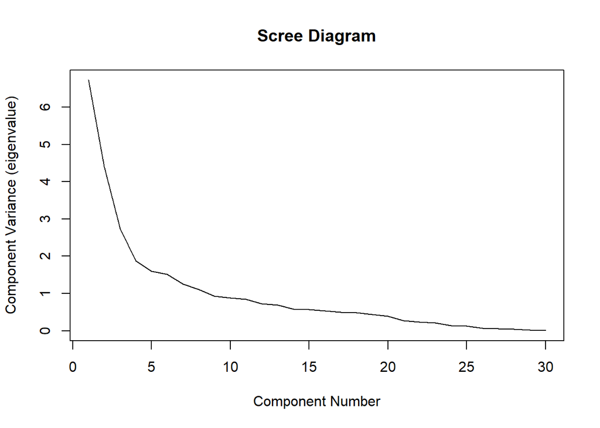

```r
plot(NFL.pc$sdev^2, xlab = "Component Number", ylab = "Component Variance (eigenvalue)", main = "Scree Diagram", type = "l")
```

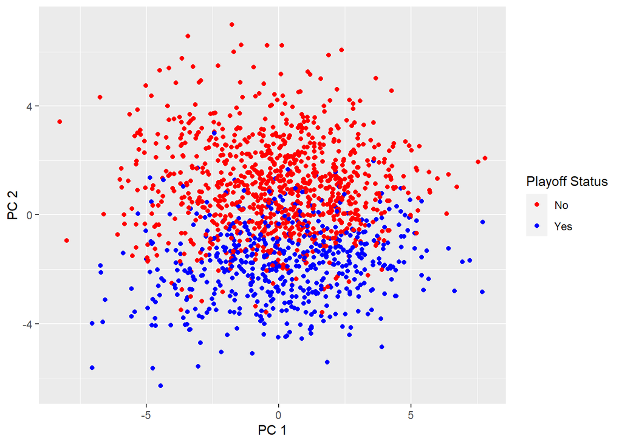

```r
qplot(NFL.pc$x[,1], NFL.pc$x[,2], col = as.factor(NFL$Playoffs)) + scale_color_manual(values = c("red", "blue"), name = "Playoff Status", labels = c("No", "Yes")) + xlab("PC 1") + ylab("PC 2")
```

```r
NFLReduced <- data.frame(NFL.pc$x[,1:8])
NFLReduced <- cbind(NFLReduced, NFL$Playoffs)
```

# Cluster Analysis

I chose to do K-means clustering in hopes to create defined tiers of teams that have a chance of making the playoffs. For both by raw and prinicpal component data, I began by looking at the between/total sum of square ratio. Based on the graphs and returns for this ratio, I determined that five clusters were the optimal amount, since there is an “elbow” at five clusters. Both of my cluster plots do not show a large amount of seperation between groups. In order to determine if my clusters were effective at distinguishing playoff versus non-playoff teams, I compared the playoff status of teams within each cluster in a bar chart. For the raw data, the clusters do not do a great job at distinguishing playoff teams. Only cluster three has more playoff teams in it than non-playoff teams. However, cluster one and four appear to be made up of mostly non-playoff teams which make this a little useful. The principal component data provides much more useful clusters. As the cluster number increases it is clear that the chance of a team being in the playoffs goes down. However, I am still not confident on using these clusters to give a definite prediction on future NFL playoff teams.

```r
NFLClust <- NFL[,7:36]
NFLClust2 <- NFLReduced[,1:8]



# K-Means Clustering on Raw Data

kmratio <- sapply(2:10, function(x)
  {NFL.km <- kmeans(NFLClust,x)
  NFL.km$betweenss/NFL.km$totss})
kmratio
```

```
## [1] 0.3513171 0.4598096 0.5320243 0.5768934 0.6065234 0.6261756 0.6481785
## [8] 0.6630148 0.6767132
```

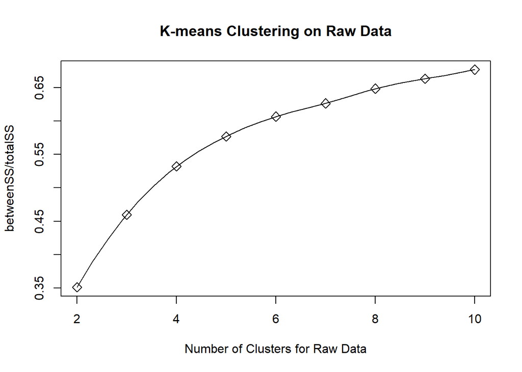

```
## integer(0)
```

```r
plot(2:10, kmratio, xlab = "Number of Clusters for Raw Data", ylab = "betweenSS/totalSS",main="K-means Clustering on Raw Data", cex=1.2, pch=5) +
lines(spline(2:10, kmratio))
```

```r
set.seed(123456789)
NFL.km <- kmeans(NFLClust, 5)
NFL.km
```

```
## K-means clustering with 5 clusters of sizes 344, 342, 247, 336, 208
##
## Cluster means:
##    PassCmp PassAY.A  PassY.C  PassY.G   PassTDG PassIntG PassSackG  RushY.A
## 1 55.63023 5.384884 11.55407 178.7456 1.0413748 1.163185  2.568695 3.869186
## 2 57.27749 6.332749 12.42719 199.3044 1.3468823 1.115169  2.374337 4.255848
## 3 62.64615 7.434413 12.24858 263.2692 1.8466149 1.009998  2.012590 4.155061
## 4 59.81190 6.415476 11.67827 223.5429 1.4038194 1.044519  2.443122 3.941964
## 5 51.35096 4.833654 12.65144 142.9909 0.9771635 1.362490  2.412822 4.011058
##    RushY.G   RushTDG RushFmbG PuntYds.R KickYds.R PuntRetTDG KickRetTDG
## 1 108.4640 0.6841737 1.744530  8.645349  20.88866 0.02277478 0.02116152
## 2 136.4132 1.0303160 1.764470  9.126023  21.54298 0.02537072 0.02186369
## 3 113.5551 0.9554037 1.473684  8.997976  21.91134 0.02600090 0.02329622
## 4 103.4351 0.7299107 1.517001  8.961310  21.90089 0.02466931 0.01860119
## 5 141.2462 0.9490804 2.094847  8.197596  21.77404 0.02440095 0.01920692
```

[output cut: 69 more lines]

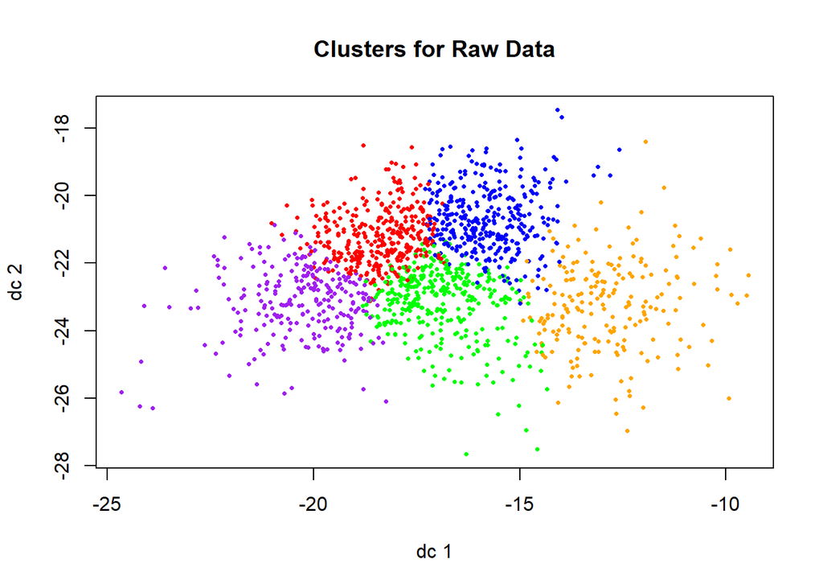

```r
vcol <- c("blue", "green", "purple", "red", "orange", "black")
plotcluster(NFLClust, NFL.km$cluster, method="dc", cex=.5, pch = 16, col=vcol[NFL.km$cluster], main = "Clusters for Raw Data")
```

```r
# K-Means clustering on Principal Component Data

kmratio2 <- sapply(2:10, function(x)
  {NFL.km <- kmeans(NFLClust2,x)
  NFL.km$betweenss/NFL.km$totss})
kmratio2
```

```
## [1] 0.2045196 0.2970084 0.3522935 0.3934674 0.4195137 0.4443953 0.4674701
## [8] 0.4882396 0.4962895
```

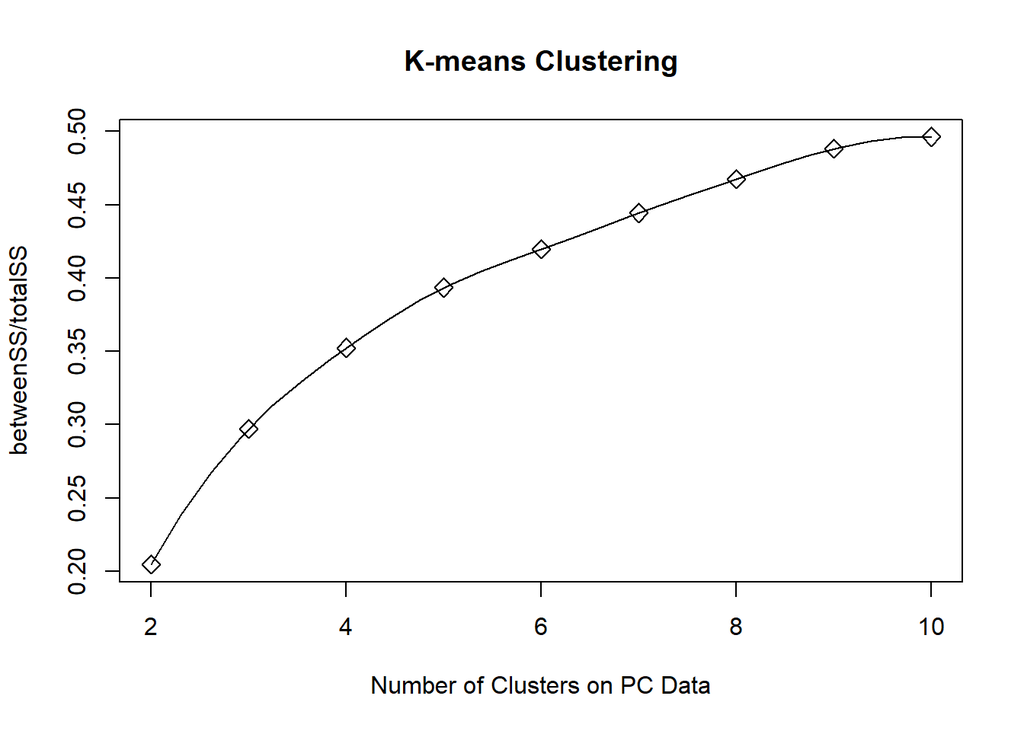

```
## integer(0)
```

```r
plot(2:10, kmratio2, xlab = "Number of Clusters on PC Data", ylab = "betweenSS/totalSS",main="K-means Clustering", cex=1.2, pch=5) +
lines(spline(2:10, kmratio2))
```

```r
set.seed(123456789)
NFL.km2 <- kmeans(NFLClust2, 5)
NFL.km2
```

```
## K-means clustering with 5 clusters of sizes 380, 196, 310, 268, 323
##
## Cluster means:
##          PC1        PC2        PC3         PC4          PC5         PC6
## 1 -0.1773550 -1.7180171  0.7053959 -0.24638231 -0.145784258  0.02746351
## 2 -3.7866876 -1.3973229 -0.5440973  0.42865580  0.310541587 -0.09327716
## 3  3.2919693 -0.5137307 -0.6550805  0.03327667  0.129991342 -0.16918602
## 4 -1.8412004  1.9771378 -1.1419942 -0.47615825 -0.174989799  0.12613389
## 5  0.8746653  1.7216885  1.0765387  0.39288974  0.003504078  0.08201230
##            PC7         PC8
## 1  0.149043698  0.21494134
## 2 -0.219343862 -0.19022735
## 3 -0.057488561 -0.21197718
## 4  0.011116059 -0.09499151
## 5  0.003706321  0.14482198
```

[output cut: 51 more lines]

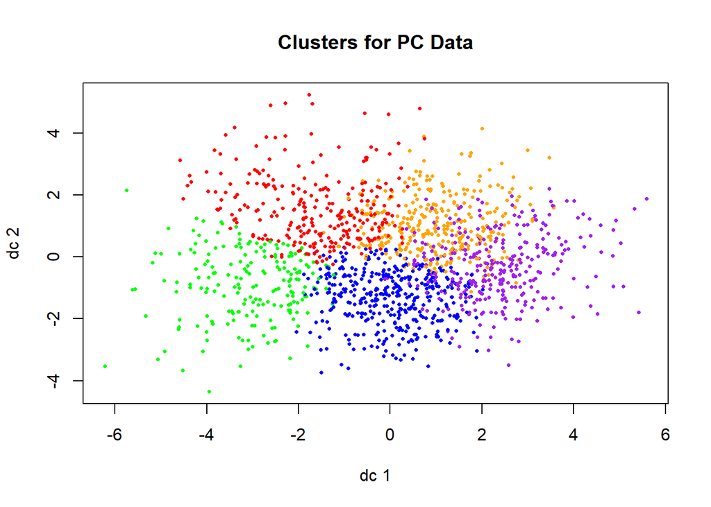

```r
vcol <- c("blue", "green", "purple", "red", "orange", "black")
plotcluster(NFLClust2, NFL.km2$cluster, method="dc", cex=.5, pch = 16, col=vcol[NFL.km2$cluster], main= "Clusters for PC Data")
```

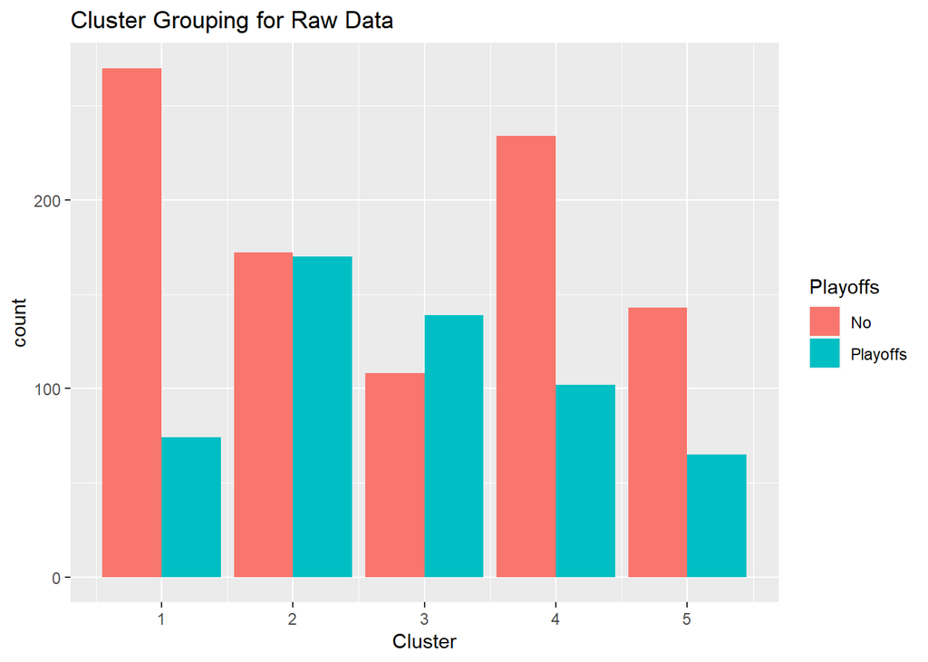

```r
# Experimenting

names <- c("Playoffs", "Raw", "PC")

Cluster <- data.frame(cbind(NFL[,6],NFL.km$cluster, NFL.km2$cluster))

colnames(Cluster) <- names
Cluster$Playoffs <- as.factor(Cluster$Playoffs)
Cluster$Playoffs <- revalue(Cluster$Playoffs,c("0"="No", "1"="Playoffs"))



ggplot(Cluster, aes(x=Raw, fill=Playoffs)) + geom_bar(position = "dodge") + xlab("Cluster") + ggtitle("Cluster Grouping for Raw Data")
```

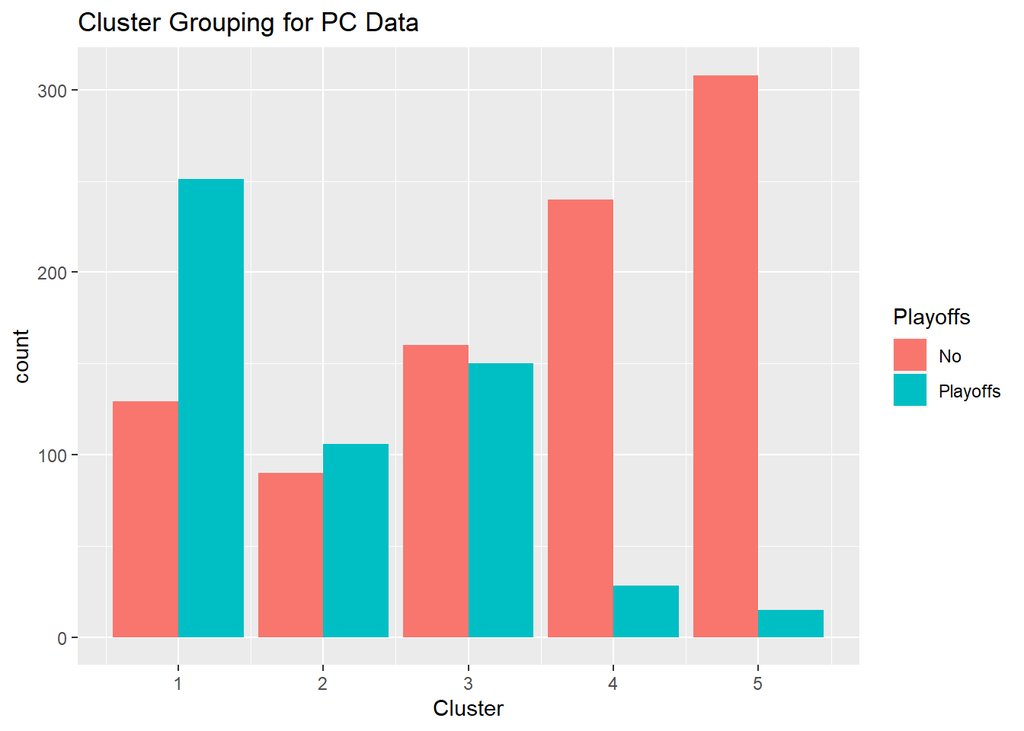

```r
ggplot(Cluster, aes(x=PC, fill=Playoffs)) + geom_bar(position="dodge") + xlab("Cluster") + ggtitle("Cluster Grouping for PC Data")
```

# Discriminant Analysis

For my discriminant analyses, I began by performing a box M-test to see if I should consider using a quadratic discriminant as well. Both of the box M-tests returned a signficant value meaning that I will be considering a quadratic disriminant when doing my analysis. I then calculated the historic probability of a team making the playoffs, seen in PlayoffRatioAllTime to use as one of my priors. Next, I used the current odds of making the playoffs 14/32 as another prior to evaluate. Then, I used a 2/3 sized sample of teams that did and did not make the playoffs to create a training index. I used this training index and my priors to create a loop. This loop was ran 100 times, and the mean testing error for each test was collected. I found that the linear discriminant always had a lower testing error, and the historic playoff ratio prior always provided the lowest testing error. However, I will be selecting the analyses with the new playoff ratio, as it only has around .5% more error, and is more applicable to today’s NFL playoff situation.

Using my second discriminant analysis, I plugged in my dataset for NFL teams this season to create playoff predictions. Based on current NFL standings (as of week 11 in the season), the predictions were very successful. Each team that is listed is currently in a playoff spot, although there are some ties. The only issue with my predictions is that it only has 13 teams making the playoffs rather than 14. This can be explained by the fact my data does not take into account divisions or conferences. In the NFL seven teams make the playoffs from each conference. Each conference has four divisions in which each division winner is awarded an automatic playoff bid. The remaining spots are given to the three teams with the next best records, known as wildcard teams. My analysis did place seven teams in the playoffs for one conference, the AFC, however, the NFC only had six. This can be explained by the one division, the NFC East. Comprised of the Eagles, Giants, Cowboys, and Football Team, the NFC East is currently having one of the worst starts for a division in NFL history. Naturally, bad teams do not have the best stats, which is likely why my model excluded all of the NFC East.

```r
## Box M Test
boxM(NFL[,7:36], NFL$Playoffs)
```

```
##
##  Box's M-test for Homogeneity of Covariance Matrices
##
## data:  NFL[, 7:36]
## Chi-Sq (approx.) = 983.23, df = 465, p-value < 2.2e-16
```

```r
boxM(NFLReduced[,1:8], NFLReduced$`NFL$Playoffs`)
```

```
##
##  Box's M-test for Homogeneity of Covariance Matrices
##
## data:  NFLReduced[, 1:8]
## Chi-Sq (approx.) = 105.3, df = 36, p-value = 1.027e-08
```

```r
# Prepping Data and Deciding On Prior Numbers
NFLDA <- NFL %>% dplyr::select(2, 6:36)
NFLDA$Playoffs[NFLDA$Playoffs==0] ="No"
NFLDA$Playoffs[NFLDA$Playoffs==1] = "Yes"
NFLPlayoffCount <- NFLDA %>% group_by(Playoffs) %>% tally()
NFLPlayoffCount
```

```
## # A tibble: 2 x 2
##   Playoffs     n
##   <chr>    <int>
## 1 No         927
## 2 Yes        550
```

```r
PlayoffRatioAllTime = 550/(927+550)
PlayoffRatioAllTime
```

```
## [1] 0.3723764
```

```r
PlayoffRatioCurrent = 14/32
PlayoffRatioCurrent
```

```
## [1] 0.4375
```

```r
NFLDA$Playoffs <- as.factor(NFLDA$Playoffs)

NFLDA <- NFLDA[order(NFLDA$Playoffs), ]


# Analysis
index.no <- c(1:927)
index.yes <- c(928:1477)



error.lda1 = c()
error.lda2 = c()
error.qda1 = c()
error.qda2 = c()



for(i in 1:100) {
  train.index.no = sample(index.no, size= 618)
  train.index.yes = sample(index.yes, size=367)
  train.index = c(train.index.no, train.index.yes)



  lda1 = lda(Playoffs~PassCmp+ PassAY.A+ PassY.C+ PassY.G+ PassTDG+ PassIntG+ PassSackG+ RushY.A+ RushY.G+ RushTDG+ RushFmbG+ PuntYds.R+ KickYds.R+ PuntRetTDG+ KickRetTDG+ APYdG+ FG+ XP+ Yds.Punt+ DefY.P+ DefRushY.A+ DefPAG+ DefTOG+ DefFirstDownG+ DefPassYdsG+ DefPassTDG+ DefRushYdsG+ DefRushTDG+ DefPenG+ DefPenFirstG, data=NFLDA, prior=c(.628, .372), CV=FALSE, subset = train.index)

  lda2 = lda(Playoffs~PassCmp+ PassAY.A+ PassY.C+ PassY.G+ PassTDG+ PassIntG+ PassSackG+ RushY.A+ RushY.G+ RushTDG+ RushFmbG+ PuntYds.R+ KickYds.R+ PuntRetTDG+ KickRetTDG+ APYdG+ FG+ XP+ Yds.Punt+ DefY.P+ DefRushY.A+ DefPAG+ DefTOG+ DefFirstDownG+ DefPassYdsG+ DefPassTDG+ DefRushYdsG+ DefRushTDG+ DefPenG+ DefPenFirstG, data=NFLDA, prior=c(.5625, .4375), CV=FALSE, subset = train.index)

  qda1= qda(Playoffs~PassCmp+ PassAY.A+ PassY.C+ PassY.G+ PassTDG+ PassIntG+ PassSackG+ RushY.A+ RushY.G+ RushTDG+ RushFmbG+ PuntYds.R+ KickYds.R+ PuntRetTDG+ KickRetTDG+ APYdG+ FG+ XP+ Yds.Punt+ DefY.P+ DefRushY.A+ DefPAG+ DefTOG+ DefFirstDownG+ DefPassYdsG+ DefPassTDG+ DefRushYdsG+ DefRushTDG+ DefPenG+ DefPenFirstG, data=NFLDA, prior=c(.628, .372), CV=FALSE, subset = train.index)

  qda2 = qda(Playoffs~PassCmp+ PassAY.A+ PassY.C+ PassY.G+ PassTDG+ PassIntG+ PassSackG+ RushY.A+ RushY.G+ RushTDG+ RushFmbG+ PuntYds.R+ KickYds.R+ PuntRetTDG+ KickRetTDG+ APYdG+ FG+ XP+ Yds.Punt+ DefY.P+ DefRushY.A+ DefPAG+ DefTOG+ DefFirstDownG+ DefPassYdsG+ DefPassTDG+ DefRushYdsG+ DefRushTDG+ DefPenG+ DefPenFirstG, data=NFLDA, prior=c(.5625, .4375), CV=FALSE, subset = train.index)

  error.lda1[i] = 1 - mean(predict(lda1, NFLDA[-train.index, ])$class == NFLDA[-train.index, ]$Playoffs)
  error.lda2[i] = 1 - mean(predict(lda2, NFLDA[-train.index, ])$class == NFLDA[-train.index, ]$Playoffs)

  error.qda1[i] = 1 - mean(predict(qda1, NFLDA[-train.index, ])$class == NFLDA[-train.index, ]$Playoffs)
error.qda2[i] = 1 - mean(predict(qda2, NFLDA[-train.index, ])$class == NFLDA[-train.index, ]$Playoffs)

}

c(mean(error.lda1), mean(error.lda2), mean(error.qda1), mean(error.qda2))
```

```
## [1] 0.1477846 0.1512398 0.1887195 0.1912602
```

```r
# Testing NFL 2020 data

Predictions <- lda2 %>% predict(NFL2020[,7:36])
PlayoffPredictions <- data.frame(NFL2020$Tm, Predictions$class)
names <- c("Team", "Playoffs")
colnames(PlayoffPredictions) <- names
PlayoffPredictions
```

```
##                        Team Playoffs
## 1             Buffalo Bills       No
## 2            Miami Dolphins      Yes
## 3      New England Patriots       No
## 4             New York Jets       No
## 5       Pittsburgh Steelers      Yes
## 6          Cleveland Browns       No
## 7          Baltimore Ravens      Yes
## 8        Cincinnati Bengals       No
## 9        Indianapolis Colts      Yes
## 10         Tennessee Titans      Yes
## 11           Houston Texans       No
## 12     Jacksonville Jaguars       No
## 13       Kansas City Chiefs      Yes
## 14        Las Vegas Raiders      Yes
```

[output cut: 18 more lines]

## Conclusions

With the NFL being a large league in terms of money, team sizes, and positions, it is invetable that models will likely be complex and not have straight foward answers. This appears to be the same case for most of my findings, however, there are a few things that I can conclude. For starters, special teams does in fact matter. Also, since special teams players are usually the cheapest, NFL general managers should target these positions to boost their teams success. Next, it is nearly impossible to pin down a specific position that will make or break an NFL team’s season. My Bonferroni confidence intervals and principal component analysis provided convuluted results, suggesting that each aspect of the game is vital to a teams success. Finally, cluster analysis may be useful at creating tiers of teams, but discriminant analysis is the most useful in terms of predicting whether a team will make the playoffs without considering wins.

I believe that this analyis has one large limitation revolving around my discriminant analysis. I have already mentioned this, but my discriminant analysis had no knowledge of the division or conference structure within the NFL. Although the predictions still turned out very well, I think that they could be improved upon. In the future, one should construct an analysis to predict a division winner, and then construct a seperate analysis to predict the wildcard teams from the remaining teams. This will ensure that the correct format is followed and provide a more accurate. In the future, I would like to perform similar analyses to predict Superbowl winners, however this would likely be much less accurate because only 1/32 teams can win it.

## Citations

Colangelo, M. (2019, July 16). The NFL made roughly $16 billion in revenue last year. Retrieved November 21, 2020, from https://touchdownwire.usatoday.com/2019/07/15/nfl-revenue-owner s-players-billions/